# DS6

10/5/2020

# Linear regression with categorical variables

- Take away message: `lm(y~factor(x))` is a handy way of comparing means across subgroups in `x`.

```r
library(ggplot2)
library(dplyr)
library(moderndive)
df = txhousing
```

## Exercise: Data exploration

Try to answer the following questions using what you have learned so far about R and Rstudio: 1. What is the dataset about? Housing sales in TX 2. What does `median` stand for? Median sale price 3. How is `median` related to `year`? Median sale price is calculated per month in a specific year.

```r
# Type your code here
# Q1: What is the dataset about?
help(txhousing)
```

```
## starting httpd help server ... done
```

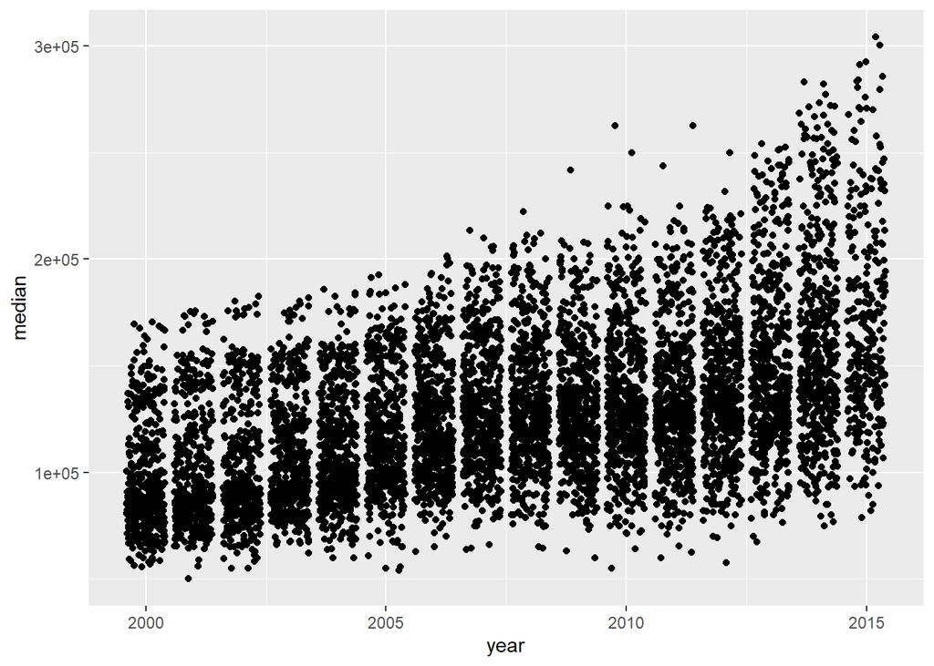

```r
# Q2:
# Then, look in the help doc for "median"
# Q3: to get a general sense, plotting a scatter plot can be a good start
ggplot(data = df, mapping = aes(x = year, y = median)) +
    # geom_point()
    geom_jitter()
```

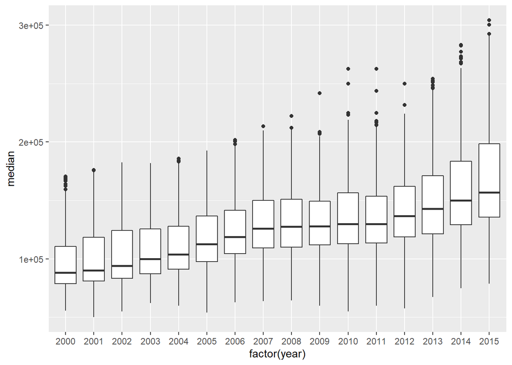

```r
# Alternative plot
df %>%
    ggplot(aes(x = factor(year), y = median)) +
    geom_boxplot()
```

## Discussion: how to model median sale price as a function of year?

1. Can you predict the `median` sale price for 2016? If yes, what kind of a model would we need? Linear regression model.
2. How are the “estimated means of the `median` (median sale price)” different between years? Looks like a very slight increase from year to year.

We can model the median sale price using year in two ways - 1) treat year as a continuous variable, and 2) treat year as a categorical variable. The objective is to understand the role of these two models in answering the questions above ## `year` as a continous variable

```r
lm_fit_years_conti = lm(median ~ year, data=df)
get_regression_table(lm_fit_years_conti)
```

```
## # A tibble: 2 x 7
##   term       estimate std_error statistic p_value  lower_ci  upper_ci
##   <chr>         <dbl>     <dbl>     <dbl>   <dbl>     <dbl>     <dbl>
## 1 intercept -8307960.  163656.      -50.8       0 -8628769. -7987152.
## 2 year          4202.      81.5      51.5       0     4042.     4362.
```

```r
get_regression_summaries(lm_fit_years_conti)
```

```
## # A tibble: 1 x 8
##   r_squared adj_r_squared         mse   rmse  sigma statistic p_value    df
##       <dbl>         <dbl>       <dbl>  <dbl>  <dbl>     <dbl>   <dbl> <dbl>
## 1      0.25          0.25 1047080944. 32359. 32363.     2657.       0     2
```

```r
lm_fit_years_as_factor = lm(median ~ factor(year), data=df )
#get_regression_summaries(lm_fit_years_as_factor) # Note, this line will fail to knit. Comment it out when knitting for submission.
```

```r
df_year_as_cat = df %>% mutate(year = factor(year))
lm_fit_years_as_factor = lm(median ~ year, data=df_year_as_cat )
get_regression_table(lm_fit_years_as_factor)
```

```
## # A tibble: 16 x 7
##    term      estimate std_error statistic p_value lower_ci upper_ci
##    <chr>        <dbl>     <dbl>     <dbl>   <dbl>    <dbl>    <dbl>
##  1 intercept   96442      1517.     63.6    0       93469.   99415.
##  2 year2001     4360.     2144.      2.03   0.042     157.    8562.
##  3 year2002     7923.     2174.      3.64   0        3662.   12184.
##  4 year2003    11566.     2121.      5.45   0        7409.   15724.
##  5 year2004    14655.     2099.      6.98   0       10541.   18769.
##  6 year2005    21942.     2094.     10.5    0       17838.   26046.
##  7 year2006    27821.     2069.     13.4    0       23766.   31877.
##  8 year2007    33715.     2064.     16.3    0       29668.   37761.
##  9 year2008    34856.     2061.     16.9    0       30815.   38897.
## 10 year2009    35042.     2052.     17.1    0       31020.   39064.
## 11 year2010    38720.     2043.     18.9    0       34714.   42726.
## 12 year2011    38383.     2044.     18.8    0       34375.   42390.
## 13 year2012    45061.     2043.     22.1    0       41055.   49066.
## 14 year2013    53491.     2044.     26.2    0       49483.   57498.
## 15 year2014    62708.     2043.     30.7    0       58702.   66713.
## 16 year2015    72223.     2361.     30.6    0       67594.   76852.
```

```r
get_regression_summaries(lm_fit_years_as_factor)
```

```
## # A tibble: 1 x 8
##   r_squared adj_r_squared         mse   rmse  sigma statistic p_value    df
##       <dbl>         <dbl>       <dbl>  <dbl>  <dbl>     <dbl>   <dbl> <dbl>
## 1      0.26         0.258 1033066523. 32141. 32174.      186.       0    16
```

In the output above, which year is the reference year? 2000

## What does `y ~ factor(year)` really tells us?

```r
mean_of_median_price_by_year = df %>%
    group_by(year) %>%
    summarise(mean_of_median_price = mean(median, na.rm = TRUE))
mean_of_reference_group = mean_of_median_price_by_year$mean_of_median_price[1]

mean_of_median_price_by_year %>%
    mutate(
        the_diff = mean_of_median_price - mean_of_reference_group
    )
```

```
## # A tibble: 16 x 3
##     year mean_of_median_price the_diff
##    <int>                <dbl>    <dbl>
##  1  2000               96442        0
##  2  2001              100802.    4360.
##  3  2002              104365.    7923.
##  4  2003              108008.   11566.
##  5  2004              111097.   14655.
##  6  2005              118384.   21942.
##  7  2006              124263.   27821.
##  8  2007              130157.   33715.
##  9  2008              131298.   34856.
## 10  2009              131484.   35042.
## 11  2010              135162.   38720.
## 12  2011              134825.   38383.
## 13  2012              141503.   45061.
## 14  2013              149933.   53491.
## 15  2014              159150.   62708.
## 16  2015              168665.   72223.
```

## Let’s alternate the “reference group” and see how the model estimate changes

### Demo: reordering a factor variable

1. We can change how different levels of a factor variable are “ordered” by specifying the order by hand
2. By default, in the `lm()`-regression, the first “group” in the factor variable is taken as the reference group.

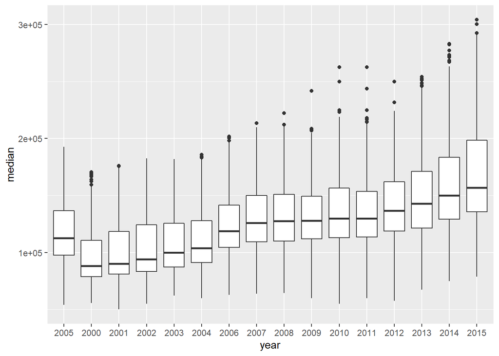

```r
df %>% mutate(
    # This is one way we can "change the reference group"
    year = factor(year, levels = c(2005,
                                   2000:2004, 2006:2015 ))
    ) %>%
    ggplot(aes(x = year, y = median)) +
    geom_boxplot()
```

### Exercise: use the new `year` variable for regressoin

```r
# Type your code here:

# Assign the adjusted dataframe to a variable
df_year_as_cat_2005_as_refgroup = df %>% mutate(year = factor(year, levels = c(2005, 2000:2004, 2006:2015)))

#get_regression_table(lm_fit_years_reordered)

# estimate the linear model with year as a categorical variable
lm_fit_years_reordered = lm(median ~ year, data=df_year_as_cat_2005_as_refgroup )

# use get_regression_table() to check what does the
get_regression_table(lm_fit_years_reordered)
```

```
## # A tibble: 16 x 7
##    term      estimate std_error statistic p_value lower_ci upper_ci
##    <chr>        <dbl>     <dbl>     <dbl>   <dbl>    <dbl>    <dbl>
##  1 intercept  118384.     1443.     82.0    0      115555.  121213.
##  2 year2000   -21942.     2094.    -10.5    0      -26046.  -17838.
##  3 year2001   -17583.     2092.     -8.40   0      -21684.  -13481.
##  4 year2002   -14019.     2123.     -6.60   0      -18181.   -9858.
##  5 year2003   -10376.     2069.     -5.01   0      -14432.   -6320.
##  6 year2004    -7288.     2046.     -3.56   0      -11299.   -3277.
##  7 year2006     5879.     2015.      2.92   0.004    1928.    9830.
##  8 year2007    11772.     2011.      5.86   0        7831.   15714.
##  9 year2008    12914.     2008.      6.43   0        8977.   16850.
## 10 year2009    13099.     1998.      6.56   0        9183.   17016.
## 11 year2010    16778.     1989.      8.43   0       12878.   20678.
## 12 year2011    16440.     1990.      8.26   0       12539.   20342.
## 13 year2012    23118.     1989.     11.6    0       19218.   27018.
## 14 year2013    31548.     1990.     15.9    0       27647.   35450.
## 15 year2014    40766.     1989.     20.5    0       36866.   44665.
## 16 year2015    50281.     2315.     21.7    0       45743.   54819.
```

## Exercise: again, what does `y ~ factor(year)` really tells us?

```r
# Adjust the code from the chunk under section "What does `y ~ factor(year)` really tells us?"
mean_of_median_price_by_year = df_year_as_cat_2005_as_refgroup %>%
    group_by(year) %>%
    summarise(mean_of_median_price = mean(median, na.rm = TRUE))
mean_of_reference_group = mean_of_median_price_by_year$mean_of_median_price[1]

mean_of_median_price_by_year %>%
    mutate(the_diff = mean_of_median_price - mean_of_reference_group)
```

```
## # A tibble: 16 x 3
##    year  mean_of_median_price the_diff
##    <fct>                <dbl>    <dbl>
##  1 2005               118384.       0
##  2 2000                96442   -21942.
##  3 2001               100802.  -17583.
##  4 2002               104365.  -14019.
##  5 2003               108008.  -10376.
##  6 2004               111097.   -7288.
##  7 2006               124263.    5879.
##  8 2007               130157.   11772.
##  9 2008               131298.   12914.
## 10 2009               131484.   13099.
## 11 2010               135162.   16778.
## 12 2011               134825.   16440.
## 13 2012               141503.   23118.
## 14 2013               149933.   31548.
## 15 2014               159150.   40766.
## 16 2015               168665.   50281.
```

Going back to the two questions we asked in the beginning: 1. Can you predict the `median` sale price for 2016? If yes, what kind of a model would we need? With lm(median ~ year), if year is counted as a continuous variable, we can calculate a predictive model for 2016. 2. How are the “estimated means of the `median` (median sale price)” different between years? lm(median ~ factor(year)) can help compare means of median across the subgroups of year.

Try writing the answers to these in your own words.